# GLM_GAM_paty

Patricia Wellhöfer

12/31/2021

```r
library(magrittr)
library(data.table)
library(dplyr)
library(lubridate)
library(caret)
library(inspectdf)
library(ggplot2)
library(GGally)
library(mgcv)
library(splitTools)
library(performance)
library(faraway)
library(knitr)
opts_chunk$set(fig.align="center", echo=TRUE)

knit_hooks$set(inline=function(x) {
  prettyNum(x, big.mark=",")
})
```

# Research Question

# Data Import and Cleaning

```r
df.ar <- fread("data/application_record.csv", stringsAsFactors = TRUE)
df.cr <- fread("data/credit_record.csv", stringsAsFactors = TRUE)
```

## View Data

### Application Record Dataframe

DAYS_BIRTH and DAYS_EMPLOYED columns count backwards from “current” day (0), -1 means yesterday, etc.  
DAYS_EMPLOYED is positive, if the person is currently unemployed.

|  | type |
| --- | --- |
| ID | integer |
| CODE_GENDER | factor |
| FLAG_OWN_CAR | factor |
| FLAG_OWN_REALTY | factor |
| CNT_CHILDREN | integer |
| AMT_INCOME_TOTAL | numeric |
| NAME_INCOME_TYPE | factor |
| NAME_EDUCATION_TYPE | factor |
| NAME_FAMILY_STATUS | factor |
| NAME_HOUSING_TYPE | factor |
| DAYS_BIRTH | integer |
| DAYS_EMPLOYED | integer |
| FLAG_MOBIL | integer |
| FLAG_WORK_PHONE | integer |
| FLAG_PHONE | integer |
| FLAG_EMAIL | integer |
| OCCUPATION_TYPE | factor |
| CNT_FAM_MEMBERS | numeric |

| ID | CODE_GENDER | FLAG_OWN_CAR | FLAG_OWN_REALTY | CNT_CHILDREN | AMT_INCOME_TOTAL | NAME_INCOME_TYPE | NAME_EDUCATION_TYPE | NAME_FAMILY_STATUS | NAME_HOUSING_TYPE | DAYS_BIRTH | DAYS_EMPLOYED | FLAG_MOBIL | FLAG_WORK_PHONE | FLAG_PHONE | FLAG_EMAIL | OCCUPATION_TYPE | CNT_FAM_MEMBERS |
| --- | --- | --- | --- | --- | --- | --- | --- | --- | --- | --- | --- | --- | --- | --- | --- | --- | --- |
| 5008804 | M | Y | Y | 0 | 427500 | Working | Higher education | Civil marriage | Rented apartment | -12005 | -4542 | 1 | 1 | 0 | 0 |  | 2 |
| 5008805 | M | Y | Y | 0 | 427500 | Working | Higher education | Civil marriage | Rented apartment | -12005 | -4542 | 1 | 1 | 0 | 0 |  | 2 |
| 5008806 | M | Y | Y | 0 | 112500 | Working | Secondary / secondary special | Married | House / apartment | -21474 | -1134 | 1 | 0 | 0 | 0 | Security staff | 2 |
| 5008808 | F | N | Y | 0 | 270000 | Commercial associate | Secondary / secondary special | Single / not married | House / apartment | -19110 | -3051 | 1 | 0 | 1 | 1 | Sales staff | 1 |
| 5008809 | F | N | Y | 0 | 270000 | Commercial associate | Secondary / secondary special | Single / not married | House / apartment | -19110 | -3051 | 1 | 0 | 1 | 1 | Sales staff | 1 |
| 5008810 | F | N | Y | 0 | 270000 | Commercial associate | Secondary / secondary special | Single / not married | House / apartment | -19110 | -3051 | 1 | 0 | 1 | 1 | Sales staff | 1 |

### Credit Record Dataframe

MONTHS_BALANCE column counts backward from “current” month (0), -1 = previous month, -2 = 2 months prior, etc.  
STATUS column: 0 = 1-29 days past due, 1 = 30-59 days past due, 2 = 60-89 days overdue, 3 = 90-119 days overdue, 4 = 120-149 days overdue, 5 = Overdue or bad debts, write-offs for more than 150 days, C = paid off that month, X = No loan for the month

|  | type |
| --- | --- |
| ID | integer |
| MONTHS_BALANCE | integer |
| STATUS | factor |

| ID | MONTHS_BALANCE | STATUS |
| --- | --- | --- |
| 5001711 | 0 | X |
| 5001711 | -1 | 0 |
| 5001711 | -2 | 0 |
| 5001711 | -3 | 0 |
| 5001712 | 0 | C |
| 5001712 | -1 | C |

## Clean Data

### Cleaning application_record.csv

Remove duplicate IDs from application_record.csv

```r
df.ar$ID %>% unique() %>% length()
## [1] 438510

duplicates <- df.ar %>% group_by(ID) %>% summarise(count = n()) %>% filter(count > 1)
df.ar.mod <- df.ar %>% filter(!ID %in% duplicates$ID)

df.ar.mod$ID %>% unique() %>% length()
## [1] 438463
```

### Cleaning credit_record.csv

The original dataset was made available on 2020-03-24, so it is presumed current month is March 2020. From months_balance we create 2 new columns indicating the month and year for each observation. Observations older than 2 years are removed.

```r
# Extract month and year from months_balance in df.cr
df.cr$month_balance <- format(as.Date("2020-03-24") %m+% months(df.cr$MONTHS_BALANCE), "%B")
df.cr$year_balance <- format(as.Date("2020-03-24") %m+% months(df.cr$MONTHS_BALANCE), "%Y") %>% as.integer(.)

# Remove records older than 2 years
df.cr.mod <- df.cr %>% filter(MONTHS_BALANCE > -24)

# Assign customer status
df.status <- df.cr.mod %>%
  group_by(ID) %>%
  summarise(cnt_status_good = length(STATUS[STATUS==0|STATUS==1|STATUS=='C']),
            cnt_status_bad = n() - cnt_status_good,
            percent_good = round(cnt_status_good / n() * 100),
            percent_bad = round(cnt_status_bad / n() * 100)) %>%
  mutate(
    customer_status_good = ifelse(percent_good >= 50, 1, 0)
  ) %>%
  select(ID, customer_status_good, percent_good, cnt_status_good, cnt_status_bad)

df.status$customer_status_good <- as.factor(df.status$customer_status_good)
```

### Join datasets

The two cleaned datasets are joined and only records where IDs exist in both are kept.

```r
df.cc.raw <- inner_join(x = df.status, y = df.ar.mod, by = "ID") %>%
  mutate(ID = as.factor(ID),
         CNT_FAM_MEMBERS = as.integer(CNT_FAM_MEMBERS),
         age_years = as.numeric(round(DAYS_BIRTH * (-1) / 365.25), 0),         # instead of DAYS_BIRTH
         work_years = as.numeric(round((DAYS_EMPLOYED * (-1) / 365.25), 0)),   # instead of DAYS_EMPLOYED, negative: Pensioner
         FLAG_MOBIL = as.factor(FLAG_MOBIL),
         FLAG_WORK_PHONE = as.factor(FLAG_WORK_PHONE),
         FLAG_PHONE = as.factor(FLAG_PHONE),
         FLAG_EMAIL = as.factor(FLAG_EMAIL))

# Change column names to lower case
setnames(df.cc.raw, tolower(names(df.cc.raw)))

# Look at the factor levels
df.cc.raw %>%
  select(-id) %>%
  select_if(is.factor) %>%
  sapply(., FUN = levels)
```

```
## $customer_status_good
## [1] "0" "1"
##
## $code_gender
## [1] "F" "M"
##
## $flag_own_car
## [1] "N" "Y"
##
## $flag_own_realty
## [1] "N" "Y"
##
## $name_income_type
## [1] "Commercial associate" "Pensioner"            "State servant"
## [4] "Student"              "Working"
##
## $name_education_type
## [1] "Academic degree"               "Higher education"
## [3] "Incomplete higher"             "Lower secondary"
## [5] "Secondary / secondary special"
##
## $name_family_status
## [1] "Civil marriage"       "Married"              "Separated"
## [4] "Single / not married" "Widow"
##
## $name_housing_type
## [1] "Co-op apartment"     "House / apartment"   "Municipal apartment"
## [4] "Office apartment"    "Rented apartment"    "With parents"
##
## $flag_mobil
## [1] "1"
##
## $flag_work_phone
## [1] "0" "1"
##
## $flag_phone
## [1] "0" "1"
##
## $flag_email
## [1] "0" "1"
##
## $occupation_type
##  [1] ""                      "Accountants"           "Cleaning staff"
##  [4] "Cooking staff"         "Core staff"            "Drivers"
##  [7] "HR staff"              "High skill tech staff" "IT staff"
## [10] "Laborers"              "Low-skill Laborers"    "Managers"
## [13] "Medicine staff"        "Private service staff" "Realty agents"
## [16] "Sales staff"           "Secretaries"           "Security staff"
## [19] "Waiters/barmen staff"
```

```r
# flag_mobil = 1 for all IDs => exclude from final dataset

# occupation_type has "" level => replace with NA
levels(df.cc.raw$occupation_type)[levels(df.cc.raw$occupation_type)==""] <- "NA"
# df.cc.raw$occupation_type %>% table()                                        # check that "" are updated as NA

# Set order of levels in education type
df.cc.raw$name_education_type <- factor(df.cc.raw$name_education_type, levels=c("Lower secondary", "Secondary / secondary special", "Incomplete higher", "Higher education", "Academic degree"), ordered = TRUE)

# Convert -ve values to NA
df.cc.raw$work_years[df.cc.raw$work_years == '-1000'] <- NA

# Select columns
# months_balance, days_birth, days_employed and flag_mobil columns are excluded
df.cc <- df.cc.raw %>%
  select(id,
         code_gender,
         age_years,
         name_education_type,
         name_income_type,
         name_housing_type,
         name_family_status,
         cnt_children,
         cnt_fam_members,
         flag_own_car,
         flag_own_realty,
         work_years,
         amt_income_total,
         occupation_type,
         flag_work_phone,
         flag_phone,
         flag_email,
         customer_status_good,
         percent_good,
         cnt_status_good,
         cnt_status_bad)
```

Remove additional duplicates. Even tough entries have different ID’s, all the other columns are the same. That’s why we only keep the unique ID’s, which also have uniqueness in all the other columns.

```r
df.cc <- df.cc[!duplicated(df.cc[c(2:17)]),]

# remove NA-values
df.cc <- na.omit(df.cc)
```

### Check Final Dataframe

```r
# Meta information from df.cc
nlevels(df.cc$id)
## [1] 32848

str(df.cc)
## tibble [7,839 x 21] (S3: tbl_df/tbl/data.frame)
##  $ id                  : Factor w/ 32848 levels "5008804","5008805",..: 1 3 4 11 12 18 21 24 25 27 ...
##  $ code_gender         : Factor w/ 2 levels "F","M": 2 2 1 2 2 1 1 1 2 2 ...
##  $ age_years           : num [1:7839] 33 59 52 46 49 29 27 30 35 32 ...
##  $ name_education_type : Ord.factor w/ 5 levels "Lower secondary"<..: 4 2 2 4 2 3 2 2 2 4 ...
##  $ name_income_type    : Factor w/ 5 levels "Commercial associate",..: 5 5 1 5 1 5 5 5 5 1 ...
##  $ name_housing_type   : Factor w/ 6 levels "Co-op apartment",..: 5 2 2 2 2 2 2 2 2 2 ...
##  $ name_family_status  : Factor w/ 5 levels "Civil marriage",..: 1 2 4 2 2 2 2 4 2 2 ...
##  $ cnt_children        : int [1:7839] 0 0 0 0 0 0 0 1 3 1 ...
##  $ cnt_fam_members     : int [1:7839] 2 2 1 2 2 2 2 2 5 3 ...
##  $ flag_own_car        : Factor w/ 2 levels "N","Y": 2 2 1 2 2 2 1 1 2 1 ...
##  $ flag_own_realty     : Factor w/ 2 levels "N","Y": 2 2 2 2 2 1 2 2 2 2 ...
##  $ work_years          : num [1:7839] 12 3 8 2 3 3 4 4 3 6 ...
##  $ amt_income_total    : num [1:7839] 427500 112500 270000 270000 135000 ...
##  $ occupation_type     : Factor w/ 19 levels "NA","Accountants",..: 1 18 16 2 10 2 10 1 10 12 ...
##  $ flag_work_phone     : Factor w/ 2 levels "0","1": 2 1 1 2 1 1 1 1 1 1 ...
##  $ flag_phone          : Factor w/ 2 levels "0","1": 1 1 2 2 1 1 2 1 1 1 ...
##  $ flag_email          : Factor w/ 2 levels "0","1": 1 1 2 2 1 1 1 1 1 1 ...
##  $ customer_status_good: Factor w/ 2 levels "0","1": 2 2 1 2 1 2 2 2 2 2 ...
##  $ percent_good        : num [1:7839] 94 50 40 100 0 100 100 100 100 93 ...
##  $ cnt_status_good     : int [1:7839] 15 12 2 6 0 24 24 24 16 14 ...
##  $ cnt_status_bad      : int [1:7839] 1 12 3 0 8 0 0 0 0 1 ...
##  - attr(*, "na.action")= 'omit' Named int [1:1502] 4 8 18 26 36 42 58 60 64 76 ...
##   ..- attr(*, "names")= chr [1:1502] "4" "8" "18" "26" ...

head(df.cc) %>% kable()
```

| id | code_gender | age_years | name_education_type | name_income_type | name_housing_type | name_family_status | cnt_children | cnt_fam_members | flag_own_car | flag_own_realty | work_years | amt_income_total | occupation_type | flag_work_phone | flag_phone | flag_email | customer_status_good | percent_good | cnt_status_good | cnt_status_bad |
| --- | --- | --- | --- | --- | --- | --- | --- | --- | --- | --- | --- | --- | --- | --- | --- | --- | --- | --- | --- | --- |
| 5008804 | M | 33 | Higher education | Working | Rented apartment | Civil marriage | 0 | 2 | Y | Y | 12 | 427500 | NA | 1 | 0 | 0 | 1 | 94 | 15 | 1 |
| 5008806 | M | 59 | Secondary / secondary special | Working | House / apartment | Married | 0 | 2 | Y | Y | 3 | 112500 | Security staff | 0 | 0 | 0 | 1 | 50 | 12 | 12 |
| 5008808 | F | 52 | Secondary / secondary special | Commercial associate | House / apartment | Single / not married | 0 | 1 | N | Y | 8 | 270000 | Sales staff | 0 | 1 | 1 | 0 | 40 | 2 | 3 |
| 5008815 | M | 46 | Higher education | Working | House / apartment | Married | 0 | 2 | Y | Y | 2 | 270000 | Accountants | 1 | 1 | 1 | 1 | 100 | 6 | 0 |
| 5008819 | M | 49 | Secondary / secondary special | Commercial associate | House / apartment | Married | 0 | 2 | Y | Y | 3 | 135000 | Laborers | 0 | 0 | 0 | 0 | 0 | 0 | 8 |
| 5008825 | F | 29 | Incomplete higher | Working | House / apartment | Married | 0 | 2 | Y | N | 3 | 130500 | Accountants | 0 | 0 | 0 | 1 | 100 | 24 | 0 |

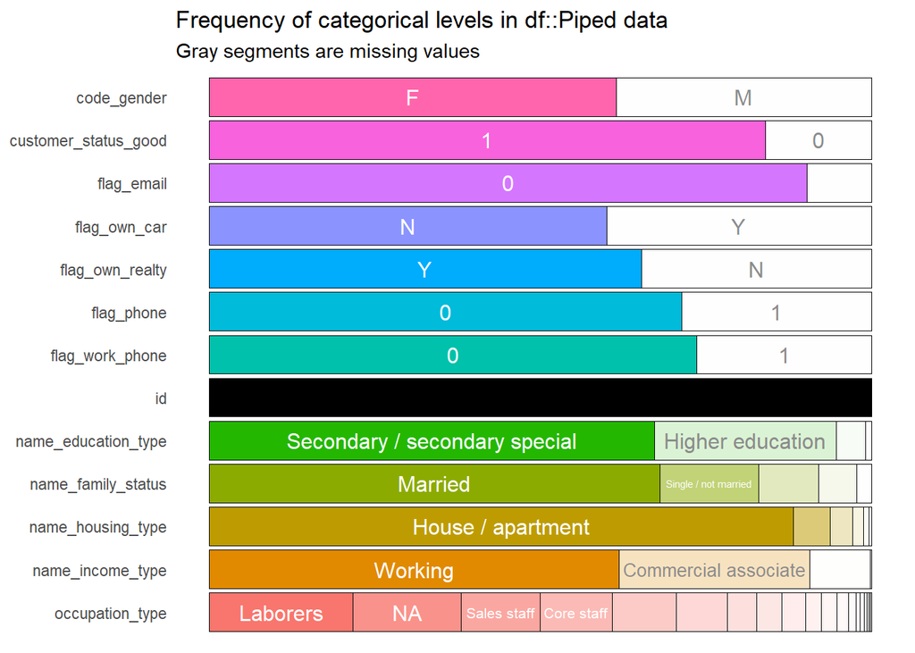

```r
df.cc %>%
  inspect_cat() %>%
  show_plot()
```

## Graphical Analysis

We would expect amt_income_total to have the strongest impact on percent_good or customer_status_good, respectively creditworthiness. We are also interested in seeing if variables such as code_gender, work_years, age_years, and name_education_type have a significant impact on the target variables.

### Overview of all the different variables

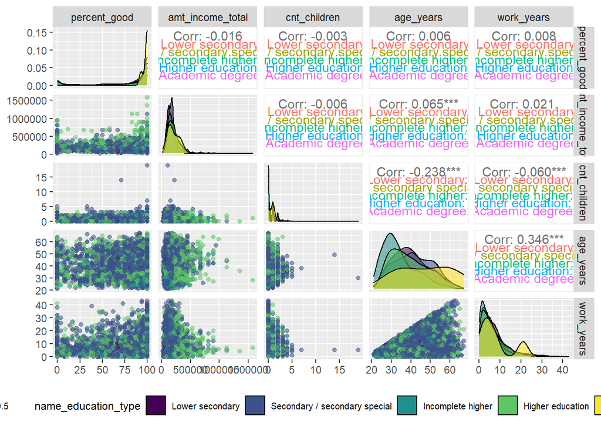

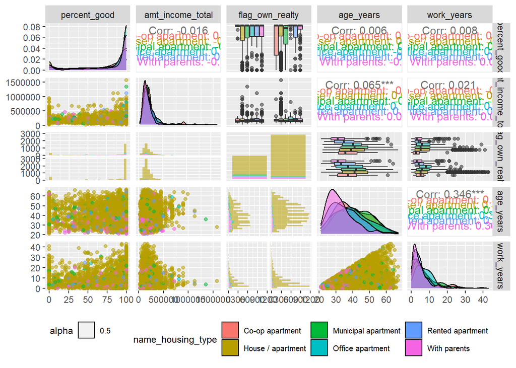

### GLM Binomial

For the GLM Binomial model we use the response variable proportion of good customers. Therefore we divide the customer status in the data set into good (1) and bad (0) customer count for creditworthiness.

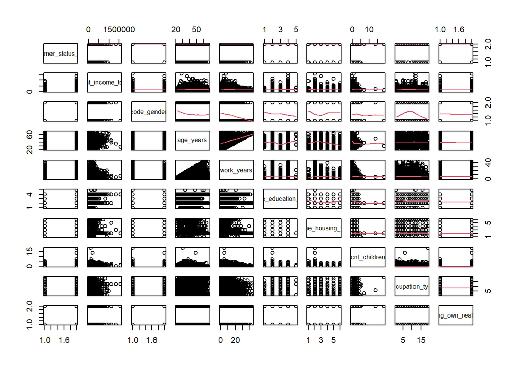

```r
pairs(customer_status_good ~ amt_income_total + code_gender + age_years + work_years + name_education_type + name_housing_type + cnt_children + occupation_type + flag_own_realty,
      data = df.cc,
      upper.panel = panel.smooth)
```

The graphical analysis indicates that the predictors have almost no effect on our dependent variable.

#### Binomial Models

We try to fit simple models with the continuous variables amt_income_total, age_years, work_years and cnt_children.

```r
glm.binom3 <- update(glm.binom2, .~. + work_years + cnt_children,
                     family = "binomial",
                     data = df.cc)
summary(glm.binom3)
```

```
##
## Call:
## glm(formula = cbind(cnt_status_good, cnt_status_bad) ~ amt_income_total +
##     age_years + work_years + cnt_children, family = "binomial",
##     data = df.cc)
##
## Deviance Residuals:
##     Min       1Q   Median       3Q      Max
## -9.2109  -0.3656   1.7151   3.0592   3.6216
##
## Coefficients:
##                    Estimate Std. Error z value Pr(>|z|)
## (Intercept)       1.464e+00  3.617e-02  40.461  < 2e-16 ***
## amt_income_total -3.296e-07  6.960e-08  -4.735 2.19e-06 ***
## age_years         1.305e-03  8.309e-04   1.571    0.116
## work_years        1.480e-03  1.206e-03   1.227    0.220
## cnt_children      1.105e-02  9.388e-03   1.178    0.239
## ---
## Signif. codes:  0 '***' 0.001 '**' 0.01 '*' 0.05 '.' 0.1 ' ' 1
##
## (Dispersion parameter for binomial family taken to be 1)
##
##     Null deviance: 88068  on 7838  degrees of freedom
## Residual deviance: 88040  on 7834  degrees of freedom
## AIC: 93907
##
## Number of Fisher Scoring iterations: 4
```

```r
exp(coef(glm.binom3)["amt_income_total"])
```

```
## amt_income_total
##        0.9999997
```

```r
ilogit(coef(glm.binom3)["amt_income_total"])
```

```
## amt_income_total
##        0.4999999
```

When interaction between all variables is included, it is interesting to see that it plays in some cases a significant role. Also the pairs plot shows interaction between different variables (model not shown).

If the categorical variable occupation_type is added to income, income is no longer significant as a predictor, but occupation_type itself shows a significant p-value (checked with drop1).

#### Visualization of the results

We plot the actual observations (blue dots) along with the predicted values for a sequence of 100 incomes that range from 27.000 to 1.5 mio.

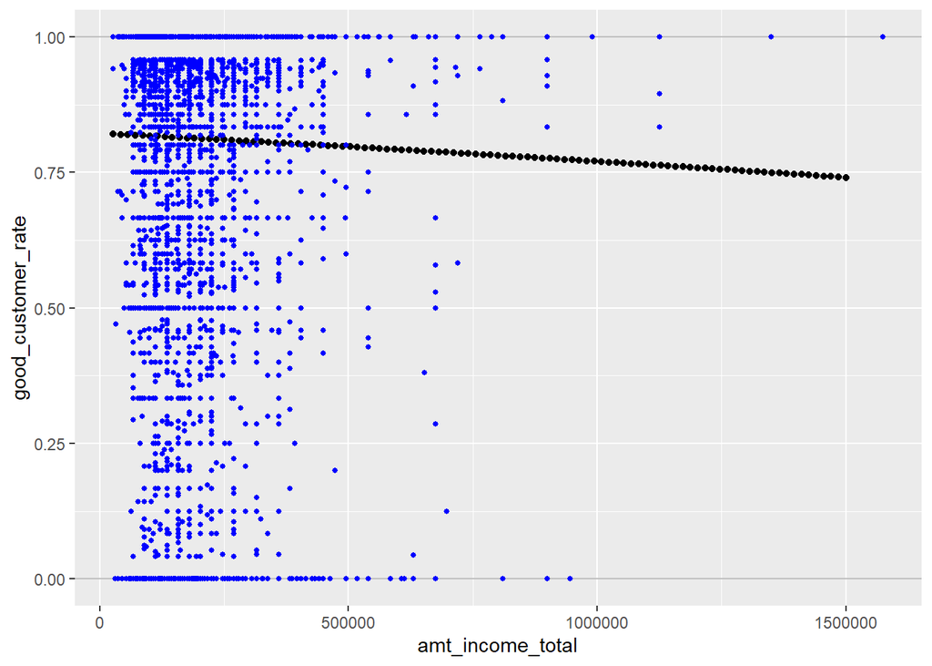

For the GLM binomial model there is in general small evidence that the predictors have significant influence. When visualizing the results we can see that we have not very much observations at the upper end of the amt_income_total scale. This makes us doubt the validity of the results. Interestingly, the predicted variables show a downward trend although the observations with the highest income are between 75% and 100% of the dependent variable good_customer_rate.

### GAM Model

For the GAM model we use the response variable percent_good, which is the percentage of good customers in our data. We start again with a basic model in which amt_income_total is the predictor. The p-value for amt_income_total is not significant. We try a more models and show the most complex model.

```r
gam.cc.3 <- update(gam.cc.2, . ~ . + s(work_years) + flag_own_realty + cnt_children)
summary(gam.cc.3)
```

```
##
## Family: gaussian
## Link function: identity
##
## Formula:
## percent_good ~ s(amt_income_total) + occupation_type + s(age_years) +
##     s(work_years) + flag_own_realty + cnt_children
##
## Parametric coefficients:
##                                      Estimate Std. Error t value Pr(>|t|)
## (Intercept)                          80.54501    1.08144  74.479   <2e-16 ***
## occupation_typeAccountants           -2.73989    2.15188  -1.273   0.2030
## occupation_typeCleaning staff        -0.83287    2.98293  -0.279   0.7801
## occupation_typeCooking staff         -4.91329    2.61402  -1.880   0.0602 .
## occupation_typeCore staff            -3.26851    1.47773  -2.212   0.0270 *
## occupation_typeDrivers               -1.73735    1.65397  -1.050   0.2936
## occupation_typeHR staff              15.71264    7.18180   2.188   0.0287 *
## occupation_typeHigh skill tech staff  0.27519    2.02240   0.136   0.8918
## occupation_typeIT staff              15.54066    8.15604   1.905   0.0568 .
## occupation_typeLaborers              -2.66083    1.23594  -2.153   0.0314 *
## occupation_typeLow-skill Laborers    -3.27889    4.77235  -0.687   0.4921
## occupation_typeManagers              -2.67971    1.57248  -1.704   0.0884 .
## occupation_typeMedicine staff         0.62077    2.20860   0.281   0.7787
## occupation_typePrivate service staff -7.84935    3.76276  -2.086   0.0370 *
## occupation_typeRealty agents         -3.87319    8.40391  -0.461   0.6449
## occupation_typeSales staff            0.97671    1.44801   0.675   0.5000
## occupation_typeSecretaries            2.11868    5.12048   0.414   0.6791
## occupation_typeSecurity staff        -4.46952    2.67272  -1.672   0.0945 .
## occupation_typeWaiters/barmen staff   4.13305    5.43454   0.761   0.4470
## flag_own_realtyY                      1.58615    0.79968   1.983   0.0474 *
## cnt_children                         -0.07636    0.47833  -0.160   0.8732
## ---
## Signif. codes:  0 '***' 0.001 '**' 0.01 '*' 0.05 '.' 0.1 ' ' 1
##
## Approximate significance of smooth terms:
##                       edf Ref.df     F p-value
## s(amt_income_total) 1.000  1.000 1.360   0.244
## s(age_years)        1.000  1.000 0.095   0.757
## s(work_years)       4.654  5.615 1.133   0.343
##
## R-sq.(adj) =  0.00293   Deviance explained = 0.632%
## GCV = 1118.5  Scale est. = 1114.6    n = 7839
```

For the smooth terms amt_income_total and age_years the edf is 1, which means that the effect on the response variable should be linear. For the smooth term work_years the edf is higher than 4 which means that the effect on the response variable is a more complex. The p-values of all smooth terms show no significance. Hence, there is no evidence that the effect differs from zero.

Parametric terms: Occupation_types shows significance for some of its levels. The same applies to level Y for the variable flag_own_reality.

#### Visualization of the smooth terms (even though not significant)

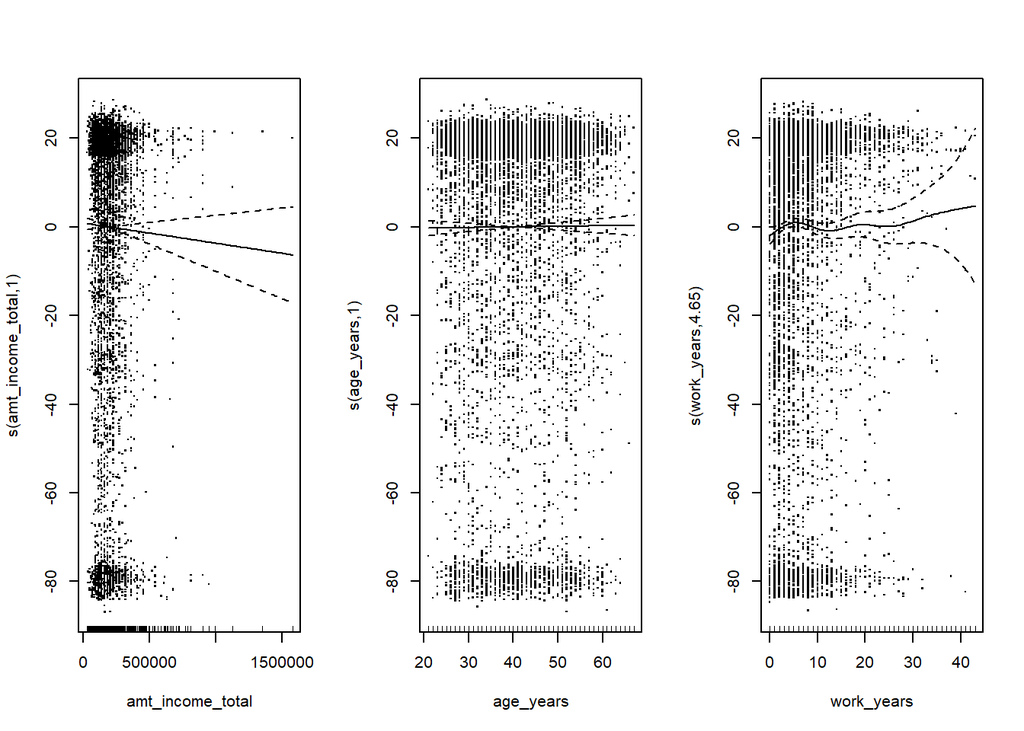

#### Cross validation GAM

For our most complex GAM model a 10-fold cross validation approach was applied. R squared was calculated to compare the three models. As the boxplot shows the median of model 3 is higher compared to the other models.

```r
set.seed(101)
folds <- createFolds(df.cc$percent_good, k = 10)

r.squared.results.gam <- lapply (folds, function(x){
  df.cc.train <- df.cc[-x, ]
  df.cc.test <- df.cc[x, ]

  gam.cc.1.train <- gam(formula = formula(gam.cc.1),
                        data = df.cc.train)

  predict.gam.cc.1.test <- predict(gam.cc.1.train,
                                   newdata = df.cc.test)

  r.squared.gam.cc.1 <- cor(predict.gam.cc.1.test,
                            df.cc.test$percent_good)^2

  gam.cc.2.train <- gam(formula = formula(gam.cc.2),
                        data = df.cc.train)

  predict.gam.cc.2.test <- predict(gam.cc.2.train,
                                   newdata = df.cc.test)

  r.squared.gam.cc.2 <- cor(predict.gam.cc.2.test,
                            df.cc.test$percent_good)^2

  gam.cc.3.train <- gam(formula = formula(gam.cc.3),
                        data = df.cc.train)

  predict.gam.cc.3.test <- predict(gam.cc.3.train,
                                   newdata = df.cc.test)

  r.squared.gam.cc.3 <- cor(predict.gam.cc.3.test,
                            df.cc.test$percent_good)^2


  return(c(r.squared.gam.cc.1, r.squared.gam.cc.2, r.squared.gam.cc.3))
})
```

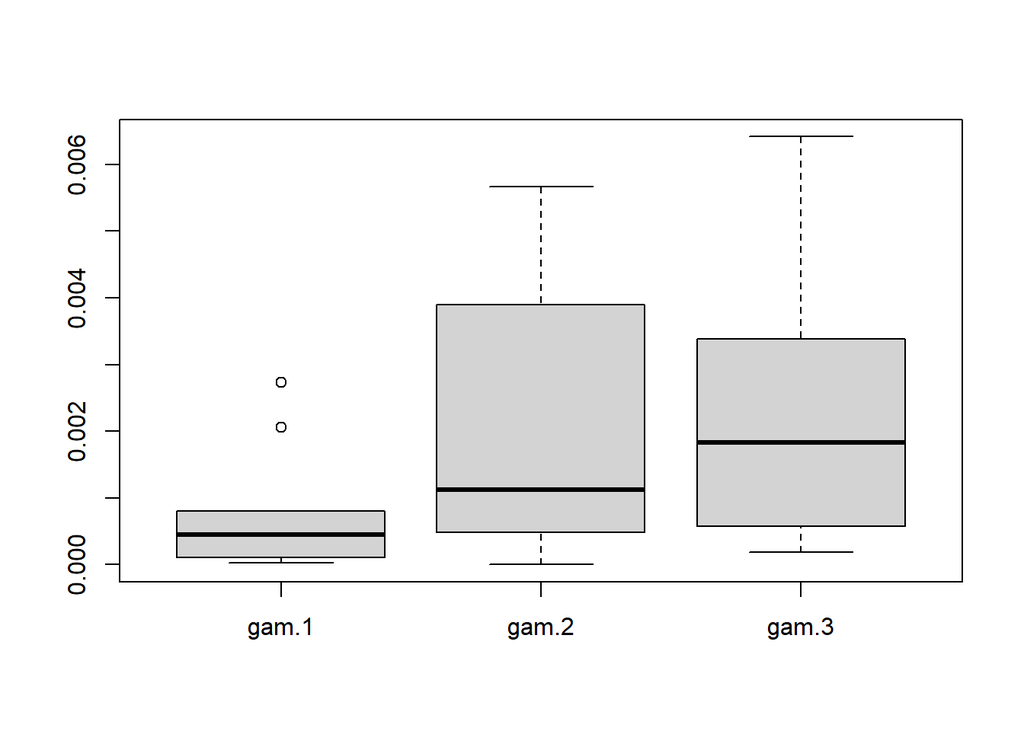

Overall, it should be noted that R squared is very low suggesting very limited predictive power of these models.